# Hilbert-space approximate copula processes

Simon Dirmeier <simon.dirmeier @ web.de>

July 2021

When reading more on copulas, I recently stumbled over the paper by Wilson and Ghahramani (2010), where they introduced *copula processes*. The paper introduces how copulas can be used to encode correlation between marginally non-Gaussian random variables using a Gaussian process. Conceptually, this seems to me to be the same as a pushforward from a GP measure to another one. After reading the paper, I was a bit puzzled what the advantage of a copula process would be in comparison to modelling the random variates conditional on a latent Gaussian process, which ultimately lead to the creation of this notebook.

We begin by shortly reviewing copulas and then implement the two models in [*Stan*](https://mc-stan.org/). Feedback and comments are welcome!

```r
suppressMessages({
  library(tidyverse)
  library(ggthemes)
  library(colorspace)

  library(cmdstanr)
  library(posterior)
  library(bayesplot)
})

set.seed(42)
color_scheme_set("darkgray")
```

# Copula processes

Following the introduction ny Wilson and Ghahramani (2010), consider a multivariate random variable $Y = (Y_1, \dots, Y_Q)$ with cumulative distribution function (cdf) $F(Y_1 \le y_1, \dots Y_Q \le y_Q)$ and marginal cdfs $F_1, \dots, F_Q$. According to Sklar’s theorem there exists an Q-copula $C: [0, 1]^Q \rightarrow [0, 1]$ such that

$$\begin{equation}
F(Y_1 \le y_1, \dots Y_Q \le y_Q) = C(F_1(y_1), \dots, F_Q(y_Q))
\end{equation}$$

Hence, with continuous marginals $C$ is given via $Q$ probability integral transforms $u_i = F_i(y_i)$, such that

$$\begin{equation}
C(u_1, \dots, u_Q) = P(U_1 \le U_1, \dots U_Q \le u_Q)
\end{equation}$$

where $U_i \sim \text{Uniform}(0, 1) \forall i = 1 \dots Q$. For instance if $C$ is chosen to be a multivariate Gaussian CDF

$$\begin{equation}
C(u_1, \dots, u_Q) = \phi(\Phi^{-1} \circle F_1(y_1), \dots, \Phi^{-1} \circle F_Q(y_Q))
\end{equation}$$

# Data

Consider a stochastic volatility model

```r
N <- 500
times  <- seq(1, 3, length.out=N)
sigmas <- sin(times) * cos(times**2) + 1
y      <- rnorm(n=length(sigmas), 0, sigmas)
```

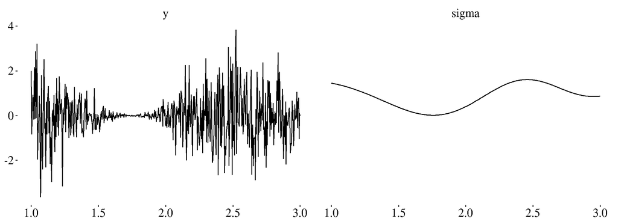

```r
data.frame(y=y, t=times, sigma=sigmas) %>%
  tidyr::pivot_longer(cols = c(y, sigma)) %>%
  dplyr::mutate(name = factor(name, levels = c("y", "sigma"))) %>%
  ggplot() +
  geom_line(aes(t, value), color="black") +
  facet_grid(. ~ name) +
  theme_tufte() +
  theme(
    axis.text = element_text(colour = "black", size = 15),
    strip.text = element_text(colour = "black", size = 15)
  ) +
  xlab(NULL) +
  ylab(NULL)
```

```r
plot.sigmas <- function(df) {
    ggplot(df) +
    geom_ribbon(aes(x=time, ymin = sigma.hat.lower, ymax = sigma.hat.upper), fill="#A1A6C8") +
    geom_line(aes(time, sigma, color="black")) +
    geom_line(aes(time, sigma.hat, color="darkblue"))  +
    scale_color_manual(values=c("black", "darkblue"),
                       labels=c("Sigma", expression(paste(widehat("Sigma"))))) +
    theme_tufte() +
    theme(
      axis.text = element_text(colour = "black", size = 15),
      strip.text = element_text(colour = "black", size = 15),
      legend.title = element_blank()
    ) +
    xlab(NULL) +
    ylab(NULL)
}
```

# Copulas processes

```r
cp.stan.file <- "./_models/cp_volatility_model.stan"
cat(readLines(cp.stan.file), sep="\n")
```

```
functions {
    vector warp(vector f, real[] beta, real[] gamma, int K) {
        vector[size(f)] y = rep_vector(0, size(f));
        for (i in 1:K) {
            y += (beta[i] ^ 2) * log(exp(f + gamma[i]) + 1.0);
        }
        return y;
    }

    real lambda(real L, int j) {
        return ((j * pi()) / (2 * L)) ^ 2;
    }

    real S(real w, real alpha, real rho) {
        return alpha^2 * sqrt(2 * pi()) * rho * exp(-0.5 * (rho * w)^2);
    }

    vector phi(vector x, real L, int j) {
        return 1 / sqrt(L) * sin(j  * pi()/(2 * L) * (x + L));
    }
}

data {
    int<lower=1> N;
    vector[N] times;
    vector[N] y;
    int<lower=1> Q;
    real<lower=0> L;
    int<lower=1> K;
}


transformed data {
    matrix[N, Q] Pmat;

    for (j in 1:Q) {
        Pmat[, j] = phi(times, L, j);
    }
}

```

[output cut: 16 more lines]

```
        }
        f = Pmat * (spd_diag .* beta_spd);
    }

   sigmas = warp(f, beta, gamma, K);
}

model {
    beta_spd ~ std_normal();
    beta ~ std_normal();
    gamma ~ inv_gamma(5, 5);
    rho ~ inv_gamma(5, 5);

    y ~ normal(0, sigmas);
}
```

```r
m <- cmdstanr::cmdstan_model(cp.stan.file)

fit <- m$sample(
  data=list(N = length(y),
            times = times,
            y = y,
            Q = 50,
            L = 5 / 2 * max(times),
            K = 1),
  seed=123,
  chains =4,
  parallel_chains=4
)
```

```r
fit$cmdstan_diagnose()
```

```
Processing csv files: /tmp/Rtmpz3cHEa/cp_volatility_model-202106201705-1-81b63e.csv, /tmp/Rtmpz3cHEa/cp_volatility_model-202106201705-2-81b63e.csv, /tmp/Rtmpz3cHEa/cp_volatility_model-202106201705-3-81b63e.csv, /tmp/Rtmpz3cHEa/cp_volatility_model-202106201705-4-81b63e.csv

Checking sampler transitions treedepth.
Treedepth satisfactory for all transitions.

Checking sampler transitions for divergences.
No divergent transitions found.

Checking E-BFMI - sampler transitions HMC potential energy.
E-BFMI satisfactory.

Effective sample size satisfactory.

Split R-hat values satisfactory all parameters.

Processing complete, no problems detected.
```

```r
sigmas.hat <- fit$draws("sigmas")
sigmas.hat.mean <- apply(as_draws_matrix(sigmas.hat), 2, mean)
sigmas.hat.ints <- t(apply(as_draws_matrix(sigmas.hat), 2, quantile, c(0.05, 0.95)))
```

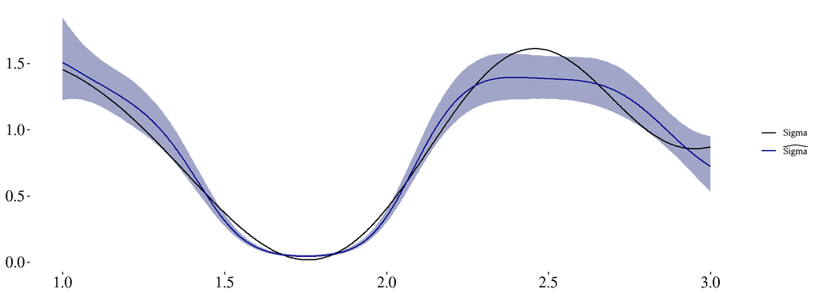

```r
tibble(time=times,
       sigma=sigmas,
       sigma.hat=sigmas.hat.mean,
       sigma.hat.lower=sigmas.hat.ints[, 1],
       sigma.hat.upper=sigmas.hat.ints[, 2]) %>%
  plot.sigmas()
```

```r
mean((sigmas - sigmas.hat.mean)**2)
```

```
[1] 0.008700944
```

# Latent Gaussian processes

```r
gp.stan.file <- "./_models/gp_volatility_model.stan"
cat(readLines(gp.stan.file), sep="\n")
```

```
functions {
    real lambda(real L, int j) {
        return ((j * pi()) / (2 * L)) ^ 2;
    }

    real S(real w, real alpha, real rho) {
        return alpha^2 * sqrt(2 * pi()) * rho * exp(-0.5 * (rho * w)^2);
    }

    vector phi(vector x, real L, int j) {
        return 1 / sqrt(L) * sin(j  * pi()/(2 * L) * (x + L));
    }
}

data {
    int<lower=1> N;
    vector[N] times;
    vector[N] y;
    int<lower=1> Q;
    real<lower=0> L;
}


transformed data {
    matrix[N, Q] Pmat;

    for (j in 1:Q) {
        Pmat[, j] = phi(times, L, j);
    }
}

parameters {
    vector[Q] beta_spd;
    real<lower=0> alpha;
    real<lower=0> rho;
     real gamma;
    real<lower=0> sigma_sigma;
    vector<lower=0>[N] sigmas;
}

```

[output cut: 9 more lines]

```
    }
}


model {
    beta_spd ~ std_normal();
    alpha ~ std_normal();
    rho ~ inv_gamma(5, 5);
     gamma ~ normal(0, 5);

    sigma_sigma  ~ std_normal();
    sigmas ~ normal(exp(f + gamma), sigma_sigma);

    y ~ normal(0, sigmas);
}
```

```r
m <- cmdstanr::cmdstan_model(gp.stan.file)

fit <- m$sample(
  data=list(N = length(y),
            times = times,
            y = y,
            Q = 50,
            L = 5 / 2 * max(times)),
  seed=123,
  chains =4,
  parallel_chains=4
)
```

```r
fit$cmdstan_diagnose()
```

```
Processing csv files: /tmp/Rtmpz3cHEa/gp_volatility_model-202106201705-1-040f1c.csv, /tmp/Rtmpz3cHEa/gp_volatility_model-202106201705-2-040f1c.csv, /tmp/Rtmpz3cHEa/gp_volatility_model-202106201705-3-040f1c.csv, /tmp/Rtmpz3cHEa/gp_volatility_model-202106201705-4-040f1c.csv

Checking sampler transitions treedepth.
3818 of 4000 (95%) transitions hit the maximum treedepth limit of 10, or 2^10 leapfrog steps.
Trajectories that are prematurely terminated due to this limit will result in slow exploration.
For optimal performance, increase this limit.

Checking sampler transitions for divergences.
182 of 4000 (4.5%) transitions ended with a divergence.
These divergent transitions indicate that HMC is not fully able to explore the posterior distribution.
Try increasing adapt delta closer to 1.
If this doesn't remove all divergences, try to reparameterize the model.

Checking E-BFMI - sampler transitions HMC potential energy.
The E-BFMI, 0.01, is below the nominal threshold of 0.3 which suggests that HMC may have trouble exploring the target distribution.
If possible, try to reparameterize the model.

The following parameters had fewer than 0.001 effective draws per transition:
  sigma_sigma, sigmas[1], sigmas[2], sigmas[3], sigmas[4], sigmas[5], sigmas[6], sigmas[7], sigmas[8], sigmas[9], sigmas[10], sigmas[11], sigmas[12], sigmas[13], sigmas[14], sigmas[15], sigmas[16], sigmas[17], sigmas[18], sigmas[19], sigmas[20], sigmas[21], sigmas[22], sigmas[23], sigmas[24], sigmas…
Such low values indicate that the effective sample size estimators may be biased high and actual performance may be substantially lower than quoted.

The following parameters had split R-hat greater than 1.1:
  beta_spd[2], beta_spd[7], beta_spd[9], beta_spd[10], beta_spd[15], beta_spd[20], beta_spd[25], beta_spd[31], beta_spd[37], beta_spd[40], beta_spd[43], beta_spd[44], beta_spd[47], beta_spd[50], alpha, rho, gamma, sigma_sigma, sigmas[1], sigmas[2], sigmas[3], sigmas[4], sigmas[5], sigmas[6], sigmas[…
Such high values indicate incomplete mixing and biased estimation.
You should consider regularizating your model with additional prior information or a more effective parameterization.

Processing complete.
```

```r
sigmas.hat <- fit$draws("sigmas")
sigmas.hat.mean <- apply(as_draws_matrix(sigmas.hat), 2, mean)
sigmas.hat.ints <- t(apply(as_draws_matrix(sigmas.hat), 2, quantile, c(0.05, 0.95)))
```

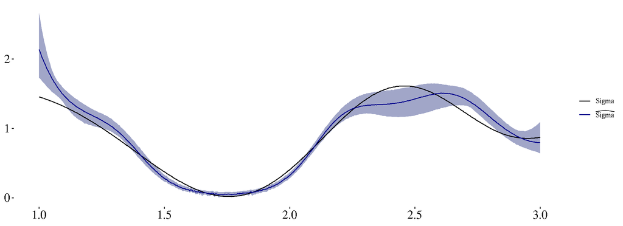

```r
tibble(time=times,
       sigma=sigmas,
       sigma.hat=sigmas.hat.mean,
       sigma.hat.lower=sigmas.hat.ints[, 1],
       sigma.hat.upper=sigmas.hat.ints[, 2]) %>%
  plot.sigmas()
```

```r
mean((sigmas - sigmas.hat.mean)**2)
```

```
[1] 0.01884889
```

# License

The notebook is licensed under a [Creative Commons Attribution-NonCommercial 4.0 International License](http://creativecommons.org/licenses/by-nc/4.0/).

# References

Solin, Arno, and Simo Särkkä. 2020. “Hilbert Space Methods for Reduced-Rank Gaussian Process Regression.” *Statistics and Computing* 30 (2): 419–46.

Wilson, Andrew G, and Zoubin Ghahramani. 2010. “Copula Processes.” In *Advances in Neural Information Processing Systems*, edited by J. Lafferty, C. Williams, J. Shawe-Taylor, R. Zemel, and A. Culotta. Vol. 23.